# bellabeat_analysis_casestudy

Takuya SHIKI

2026-03-20

# Who can keep wearing wearables?

## 1. Background

Wearable devices are widely used in today’s world. However, many of us struggle to maintain healthy habits, such as using healthcare products on a daily basis.

## 2. Project Goal

This projects aims to analyze some behavioral patterns which can influence whether or not one is going to be consistent users of wearable devices. In addition, I provide actionable insights for segmented marketing strategies at the end of this report.

## 3. Data Source

[FitBit Fitness Tracker Data (Kaggle)](https://www.kaggle.com/datasets/arashnic/fitbit)

The dataset contains activity and sleep records collected from approximately 30 users between March 2016 and May 2016.

## 4. Data Limitation

The data sets do not show when users started and finished using the devices. Therefore, my analysis focuses on a healthy habit consistency within the reported period (03.12.2016-05.12.2016), instead of a long-term retention.

Note: Sleep data are only available for a smaller subset of users from April to May.

## 5. Hypothesis

Users can be classified into three groups:

- Consistent Active Users: Those who almost always keep healthy habits (e.g., higher activity levels and more daily steps)
- Irregular Users: Those who occasionally engage in healthy behaviors (e.g., spontaneous high activities and a large fluctuation in daily steps
- Low Engagement Users: Those who show unhealthy behaviors (e.g., lower activity levels and sedentary)

## 6. Data Preparation

Overall, I decided to select daily data sets because I am interested in a daily comparison between users, rather than deepening one specific person’s activities.

The followings are the filenames and column names I chose for this analysis:

### dailyActivity_merged

- Id
- ActivityDate
- TotalSteps
- VeryActiveMinutes
- FairlyActiveMinutes
- LightlyActiveMinutes
- SedentaryMinutes
- Calories

### hourlyIntensities_merged

- Id
- ActivityHour
- TotalIntensity
- AverageIntensity

### minuteMETsNarrow_merged

- Id
- ActivityMinute
- METs

Sleep duration data to be used for supplementary explanations because of the limited availability as I mentioned.

### sleepDay_merged

- Id
- SleepDay
- TotalMinutesAsleep
- TotalTimeInBed

## 7. Data Cleaning

### 7-1. Inspect Data

The datasets were provided in two separate files covering different time periods. These files were combined into a single dataset before analysis.

```r
library(tidyverse)
daily_34 <- read.csv("data/raw_data/dailyActivity_merged_34.csv")
daily_45 <- read_csv("data/raw_data/dailyActivity_merged_45.csv")
dailyActivity <- bind_rows(
  daily_34,
  daily_45
)
nrow(daily_34)
```

```
## [1] 457
```

```r
nrow(daily_45)
```

```
## [1] 940
```

```r
nrow(dailyActivity)
```

```
## [1] 1397
```

```r
hourlyInt_34 <- read_csv("data/raw_data/hourlyIntensities_merged_34.csv")
hourlyInt_45 <- read_csv("data/raw_data/hourlyIntensities_merged_45.csv")
hourlyIntensity <- bind_rows(
  hourlyInt_34,
  hourlyInt_45
)
nrow(hourlyInt_34)
```

```
## [1] 24084
```

```r
nrow(hourlyInt_45)
```

```
## [1] 22099
```

```r
nrow(hourlyIntensity)
```

```
## [1] 46183
```

```r
minuteMets_34 <- read_csv("data/raw_data/minuteMETsNarrow_merged_34.csv")
minuteMets_45 <- read_csv("data/raw_data/minuteMETsNarrow_merged_45.csv")
minuteMETs <- bind_rows(
  minuteMets_34,
  minuteMets_45
)
nrow(minuteMets_34)
```

```
## [1] 1445040
```

```r
nrow(minuteMets_45)
```

```
## [1] 1325580
```

```r
nrow(minuteMETs)
```

```
## [1] 2770620
```

```r
sleepDay <- read_csv("data/raw_data/sleepDay_merged_45.csv")
glimpse(dailyActivity)
```

```
## Rows: 1,397
## Columns: 15
## $ Id                       <dbl> 1503960366, 1503960366, 1503960366, 150396036…
## $ ActivityDate             <chr> "3/25/2016", "3/26/2016", "3/27/2016", "3/28/…
## $ TotalSteps               <dbl> 11004, 17609, 12736, 13231, 12041, 10970, 122…
## $ TotalDistance            <dbl> 7.11, 11.55, 8.53, 8.93, 7.85, 7.16, 7.86, 7.…
## $ TrackerDistance          <dbl> 7.11, 11.55, 8.53, 8.93, 7.85, 7.16, 7.86, 7.…
## $ LoggedActivitiesDistance <dbl> 0, 0, 0, 0, 0, 0, 0, 0, 0, 0, 0, 0, 0, 0, 0, …
## $ VeryActiveDistance       <dbl> 2.57, 6.92, 4.66, 3.19, 2.16, 2.36, 2.29, 3.3…
## $ ModeratelyActiveDistance <dbl> 0.46, 0.73, 0.16, 0.79, 1.09, 0.51, 0.49, 0.8…
## $ LightActiveDistance      <dbl> 4.07, 3.91, 3.71, 4.95, 4.61, 4.29, 5.04, 3.6…
## $ SedentaryActiveDistance  <dbl> 0.00, 0.00, 0.00, 0.00, 0.00, 0.00, 0.00, 0.0…
## $ VeryActiveMinutes        <dbl> 33, 89, 56, 39, 28, 30, 33, 47, 40, 15, 43, 3…
## $ FairlyActiveMinutes      <dbl> 12, 17, 5, 20, 28, 13, 12, 21, 11, 30, 18, 18…
## $ LightlyActiveMinutes     <dbl> 205, 274, 268, 224, 243, 223, 239, 200, 244, …
## $ SedentaryMinutes         <dbl> 804, 588, 605, 1080, 763, 1174, 820, 866, 636…
## $ Calories                 <dbl> 1819, 2154, 1944, 1932, 1886, 1820, 1889, 186…
```

```r
glimpse(hourlyIntensity)
```

```
## Rows: 46,183
## Columns: 4
## $ Id               <dbl> 1503960366, 1503960366, 1503960366, 1503960366, 15039…
## $ ActivityHour     <chr> "3/12/2016 12:00:00 AM", "3/12/2016 1:00:00 AM", "3/1…
## $ TotalIntensity   <dbl> 0, 0, 0, 0, 0, 0, 0, 0, 0, 1, 26, 49, 47, 20, 121, 12…
## $ AverageIntensity <dbl> 0.000000, 0.000000, 0.000000, 0.000000, 0.000000, 0.0…
```

```r
glimpse(minuteMETs)
```

```
## Rows: 2,770,620
## Columns: 3
## $ Id             <dbl> 1503960366, 1503960366, 1503960366, 1503960366, 1503960…
## $ ActivityMinute <chr> "3/12/2016 12:00:00 AM", "3/12/2016 12:01:00 AM", "3/12…
## $ METs           <dbl> 10, 10, 10, 10, 10, 10, 10, 10, 10, 10, 10, 10, 10, 10,…
```

```r
glimpse(sleepDay)
```

```
## Rows: 413
## Columns: 5
## $ Id                 <dbl> 1503960366, 1503960366, 1503960366, 1503960366, 150…
## $ SleepDay           <chr> "4/12/2016 12:00:00 AM", "4/13/2016 12:00:00 AM", "…
## $ TotalSleepRecords  <dbl> 1, 2, 1, 2, 1, 1, 1, 1, 1, 1, 1, 1, 1, 1, 1, 1, 1, …
## $ TotalMinutesAsleep <dbl> 327, 384, 412, 340, 700, 304, 360, 325, 361, 430, 2…
## $ TotalTimeInBed     <dbl> 346, 407, 442, 367, 712, 320, 377, 364, 384, 449, 3…
```

### 7-2. Date Type Conversion

Data variables should be converted from Character type to Date or DateTime format for specifying the time range.

```r
dailyActivity <- dailyActivity %>%
  mutate(
    ActivityDate = as.Date(
      ActivityDate,
      format = "%m/%d/%Y")
  )
range(dailyActivity$ActivityDate)
```

```
## [1] "2016-03-12" "2016-05-12"
```

```r
hourlyIntensity <- hourlyIntensity %>%
  mutate(
    ActivityHour =as.POSIXct(
      ActivityHour,
      format = "%m/%d/%Y %I:%M:%S %p")
  )
range(hourlyIntensity$ActivityHour)
```

```
## [1] "2016-03-12 00:00:00 JST" "2016-05-12 15:00:00 JST"
```

```r
minuteMETs <-minuteMETs %>%
  mutate(
    ActivityMinute =as.POSIXct(
      ActivityMinute,
      format ="%m/%d/%Y %I:%M:%S %p")
  )
range(minuteMETs$ActivityMinute)
```

```
## [1] "2016-03-12 00:00:00 JST" "2016-05-12 15:59:00 JST"
```

```r
sleepDay <- sleepDay %>%
  mutate(
    SleepDay =as.Date(
      SleepDay,
      format ="%m/%d/%Y %I:%M:%S %p")
  )
range(sleepDay$SleepDay)
```

```
## [1] "2016-04-12" "2016-05-12"
```

### 7-3. Data Validation

Each table includes different number of users. The numbers are as follows:

```r
n_distinct(dailyActivity$Id)
```

```
## [1] 35
```

```r
n_distinct(hourlyIntensity$Id)
```

```
## [1] 35
```

```r
n_distinct(minuteMETs$Id)
```

```
## [1] 35
```

```r
n_distinct(sleepDay$Id)
```

```
## [1] 24
```

### 7-4. Daily-Level Aggregation

To prepare the data for analysis, the data granularity should be standardized to the daily level before creating the master table.

```r
Intensity_daily <- hourlyIntensity %>%
  mutate(Date = as.Date(ActivityHour)) %>%
  group_by(Id,Date) %>%
  summarise(
    SumIntensity = sum(TotalIntensity,na.rm = TRUE),
    AvgIntensity = mean(AverageIntensity,na.rm = TRUE),
    .groups = "drop"
  )

head(Intensity_daily)
```

```
## # A tibble: 6 × 4
##           Id Date       SumIntensity AvgIntensity
##        <dbl> <date>            <dbl>        <dbl>
## 1 1503960366 2016-03-11            0        0
## 2 1503960366 2016-03-12          601        0.417
## 3 1503960366 2016-03-13          576        0.4
## 4 1503960366 2016-03-14          385        0.267
## 5 1503960366 2016-03-15          489        0.340
## 6 1503960366 2016-03-16          425        0.295
```

```r
write_csv(Intensity_daily,
          "data/cleaned_data/Intensity_daily.csv")
```

```r
METs_daily <- minuteMETs %>%
  mutate(Date = as.Date(ActivityMinute)) %>%
  group_by(Id,Date) %>%
  summarise(
    sumMETs =sum(METs,na.rm = TRUE),
    avgMETs =mean(METs,na.rm = TRUE),
    .groups = "drop"
  )

head(METs_daily)
```

```
## # A tibble: 6 × 4
##           Id Date       sumMETs avgMETs
##        <dbl> <date>       <dbl>   <dbl>
## 1 1503960366 2016-03-11    5400    10
## 2 1503960366 2016-03-12   28100    19.5
## 3 1503960366 2016-03-13   26716    18.6
## 4 1503960366 2016-03-14   23259    16.2
## 5 1503960366 2016-03-15   26316    18.3
## 6 1503960366 2016-03-16   24554    17.1
```

```r
write_csv(METs_daily,
          "data/cleaned_data/METs_daily.csv")
```

```r
Sleep_daily <- sleepDay %>%
  rename(Date = SleepDay) %>%
  select(
    Id,
    Date,
    TotalMinutesAsleep,
    TotalTimeInBed
  )

head(Sleep_daily)
```

```
## # A tibble: 6 × 4
##           Id Date       TotalMinutesAsleep TotalTimeInBed
##        <dbl> <date>                  <dbl>          <dbl>
## 1 1503960366 2016-04-12                327            346
## 2 1503960366 2016-04-13                384            407
## 3 1503960366 2016-04-15                412            442
## 4 1503960366 2016-04-16                340            367
## 5 1503960366 2016-04-17                700            712
## 6 1503960366 2016-04-19                304            320
```

```r
write_csv(Sleep_daily,
      "data/cleaned_data/Sleep_daily.csv")
```

```r
Activity_daily <- dailyActivity %>%
  rename(Date = ActivityDate) %>%
  select(
    Id,
    Date,
    TotalSteps,
    VeryActiveMinutes,
    FairlyActiveMinutes,
    LightlyActiveMinutes,
    SedentaryMinutes,
    Calories
  )

head(Activity_daily)
```

```
##           Id       Date TotalSteps VeryActiveMinutes FairlyActiveMinutes
## 1 1503960366 2016-03-25      11004                33                  12
## 2 1503960366 2016-03-26      17609                89                  17
## 3 1503960366 2016-03-27      12736                56                   5
## 4 1503960366 2016-03-28      13231                39                  20
## 5 1503960366 2016-03-29      12041                28                  28
## 6 1503960366 2016-03-30      10970                30                  13
##   LightlyActiveMinutes SedentaryMinutes Calories
## 1                  205              804     1819
## 2                  274              588     2154
## 3                  268              605     1944
## 4                  224             1080     1932
## 5                  243              763     1886
## 6                  223             1174     1820
```

```r
write_csv(Activity_daily,
          "data/cleaned_data/Activity_daily.csv")
```

### 7-5. Finalize Master Table

The four datasets above were combined to a single master table by using Id and Date as keys.

```r
master_table <- Activity_daily %>%
  left_join(Intensity_daily,by = c("Id","Date")) %>%
  left_join(METs_daily,by =c("Id","Date")) %>%
  left_join(Sleep_daily,by =c("Id","Date"))
head(master_table)
```

```
##           Id       Date TotalSteps VeryActiveMinutes FairlyActiveMinutes
## 1 1503960366 2016-03-25      11004                33                  12
## 2 1503960366 2016-03-26      17609                89                  17
## 3 1503960366 2016-03-27      12736                56                   5
## 4 1503960366 2016-03-28      13231                39                  20
## 5 1503960366 2016-03-29      12041                28                  28
## 6 1503960366 2016-03-30      10970                30                  13
##   LightlyActiveMinutes SedentaryMinutes Calories SumIntensity AvgIntensity
## 1                  205              804     1819          305    0.2118056
## 2                  274              588     2154          571    0.3965277
## 3                  268              605     1944          451    0.3131945
## 4                  224             1080     1932          396    0.2750001
## 5                  243              763     1886          354    0.2458334
## 6                  223             1174     1820          368    0.2555556
##   sumMETs  avgMETs TotalMinutesAsleep TotalTimeInBed
## 1   22558 15.66528                 NA             NA
## 2   27191 18.88264                 NA             NA
## 3   24723 17.16875                 NA             NA
## 4   24838 17.24861                 NA             NA
## 5   23266 16.15694                 NA             NA
## 6   23721 16.47292                 NA             NA
```

```r
glimpse(master_table)
```

```
## Rows: 1,400
## Columns: 14
## $ Id                   <dbl> 1503960366, 1503960366, 1503960366, 1503960366, 1…
## $ Date                 <date> 2016-03-25, 2016-03-26, 2016-03-27, 2016-03-28, …
## $ TotalSteps           <dbl> 11004, 17609, 12736, 13231, 12041, 10970, 12256, …
## $ VeryActiveMinutes    <dbl> 33, 89, 56, 39, 28, 30, 33, 47, 40, 15, 43, 36, 2…
## $ FairlyActiveMinutes  <dbl> 12, 17, 5, 20, 28, 13, 12, 21, 11, 30, 18, 18, 12…
## $ LightlyActiveMinutes <dbl> 205, 274, 268, 224, 243, 223, 239, 200, 244, 314,…
## $ SedentaryMinutes     <dbl> 804, 588, 605, 1080, 763, 1174, 820, 866, 636, 65…
## $ Calories             <dbl> 1819, 2154, 1944, 1932, 1886, 1820, 1889, 1868, 1…
## $ SumIntensity         <dbl> 305, 571, 451, 396, 354, 368, 365, 380, 377, 438,…
## $ AvgIntensity         <dbl> 0.21180558, 0.39652771, 0.31319446, 0.27500008, 0…
## $ sumMETs              <dbl> 22558, 27191, 24723, 24838, 23266, 23721, 24026, …
## $ avgMETs              <dbl> 15.66528, 18.88264, 17.16875, 17.24861, 16.15694,…
## $ TotalMinutesAsleep   <dbl> NA, NA, NA, NA, NA, NA, NA, NA, NA, NA, NA, NA, N…
## $ TotalTimeInBed       <dbl> NA, NA, NA, NA, NA, NA, NA, NA, NA, NA, NA, NA, N…
```

```r
summary(master_table)
```

```
##        Id                 Date              TotalSteps    VeryActiveMinutes
##  Min.   :1.504e+09   Min.   :2016-03-12   Min.   :    0   Min.   :  0.00
##  1st Qu.:2.320e+09   1st Qu.:2016-04-09   1st Qu.: 3147   1st Qu.:  0.00
##  Median :4.445e+09   Median :2016-04-19   Median : 7012   Median :  2.00
##  Mean   :4.783e+09   Mean   :2016-04-19   Mean   : 7291   Mean   : 19.73
##  3rd Qu.:6.962e+09   3rd Qu.:2016-04-30   3rd Qu.:10565   3rd Qu.: 30.00
##  Max.   :8.878e+09   Max.   :2016-05-12   Max.   :36019   Max.   :210.00
##
##  FairlyActiveMinutes LightlyActiveMinutes SedentaryMinutes    Calories
##  Min.   :  0.00      Min.   :  0.0        Min.   :   0.0   Min.   :   0
##  1st Qu.:  0.00      1st Qu.:111.0        1st Qu.: 728.8   1st Qu.:1799
##  Median :  6.00      Median :195.0        Median :1057.0   Median :2115
##  Mean   : 13.45      Mean   :185.5        Mean   : 992.0   Mean   :2269
##  3rd Qu.: 18.00      3rd Qu.:262.0        3rd Qu.:1244.0   3rd Qu.:2773
##  Max.   :660.00      Max.   :720.0        Max.   :1440.0   Max.   :4900
##
##   SumIntensity     AvgIntensity       sumMETs         avgMETs
##  Min.   :   0.0   Min.   :0.0000   Min.   :  600   Min.   :10.00
##  1st Qu.: 156.0   1st Qu.:0.1146   1st Qu.:17765   1st Qu.:12.52
##  Median : 289.0   Median :0.2049   Median :20991   Median :14.70
##  Mean   : 280.6   Mean   :0.1997   Mean   :20761   Mean   :14.69
##  3rd Qu.: 396.0   3rd Qu.:0.2778   3rd Qu.:23664   3rd Qu.:16.53
##  Max.   :1024.0   Max.   :0.7111   Max.   :39857   Max.   :27.68
##  NA's   :35       NA's   :35       NA's   :35      NA's   :35
##  TotalMinutesAsleep TotalTimeInBed
##  Min.   : 58.0      Min.   : 61.0
##  1st Qu.:361.0      1st Qu.:403.0
##  Median :433.0      Median :464.0
##  Mean   :420.2      Mean   :459.3
##  3rd Qu.:492.0      3rd Qu.:526.0
##  Max.   :796.0      Max.   :961.0
##  NA's   :975        NA's   :975
```

```r
n_distinct(master_table$Id)
```

```
## [1] 35
```

```r
colSums(is.na(master_table))
```

```
##                   Id                 Date           TotalSteps
##                    0                    0                    0
##    VeryActiveMinutes  FairlyActiveMinutes LightlyActiveMinutes
##                    0                    0                    0
##     SedentaryMinutes             Calories         SumIntensity
##                    0                    0                   35
##         AvgIntensity              sumMETs              avgMETs
##                   35                   35                   35
##   TotalMinutesAsleep       TotalTimeInBed
##                  975                  975
```

```r
write_csv(master_table,
          "data/cleaned_data/master_table.csv")
```

## 8. Data Analysis

### 8-1. Correlation Analysis

Before creating user-level summary profiles, I explored the relationships of activity-related variables, such as calories, Intensity, and steps.

```r
activity_data <- master_table %>%
  select(
    TotalSteps,
    VeryActiveMinutes,
    FairlyActiveMinutes,
    LightlyActiveMinutes,
    SedentaryMinutes,
    Calories,
    SumIntensity,
    AvgIntensity,
    sumMETs,
    avgMETs
  )

correlation_act <- activity_data %>%
  cor(use = "complete.obs")

correlation_act <- round(correlation_act,2)
correlation_act
```

```
##                      TotalSteps VeryActiveMinutes FairlyActiveMinutes
## TotalSteps                 1.00              0.67                0.50
## VeryActiveMinutes          0.67              1.00                0.32
## FairlyActiveMinutes        0.50              0.32                1.00
## LightlyActiveMinutes       0.59              0.09                0.18
## SedentaryMinutes          -0.32             -0.17               -0.24
## Calories                   0.59              0.59                0.33
## SumIntensity               0.81              0.64                0.49
## AvgIntensity               0.77              0.60                0.48
## sumMETs                    0.74              0.61                0.40
## avgMETs                    0.79              0.66                0.45
##                      LightlyActiveMinutes SedentaryMinutes Calories
## TotalSteps                           0.59            -0.32     0.59
## VeryActiveMinutes                    0.09            -0.17     0.59
## FairlyActiveMinutes                  0.18            -0.24     0.33
## LightlyActiveMinutes                 1.00            -0.44     0.30
## SedentaryMinutes                    -0.44             1.00    -0.09
## Calories                             0.30            -0.09     1.00
## SumIntensity                         0.67            -0.46     0.52
## AvgIntensity                         0.66            -0.51     0.46
## sumMETs                              0.55            -0.31     0.58
## avgMETs                              0.59            -0.49     0.54
##                      SumIntensity AvgIntensity sumMETs avgMETs
## TotalSteps                   0.81         0.77    0.74    0.79
## VeryActiveMinutes            0.64         0.60    0.61    0.66
## FairlyActiveMinutes          0.49         0.48    0.40    0.45
## LightlyActiveMinutes         0.67         0.66    0.55    0.59
## SedentaryMinutes            -0.46        -0.51   -0.31   -0.49
## Calories                     0.52         0.46    0.58    0.54
## SumIntensity                 1.00         0.94    0.90    0.91
## AvgIntensity                 0.94         1.00    0.74    0.96
## sumMETs                      0.90         0.74    1.00    0.78
## avgMETs                      0.91         0.96    0.78    1.00
```

### 8-2. Feature Selection

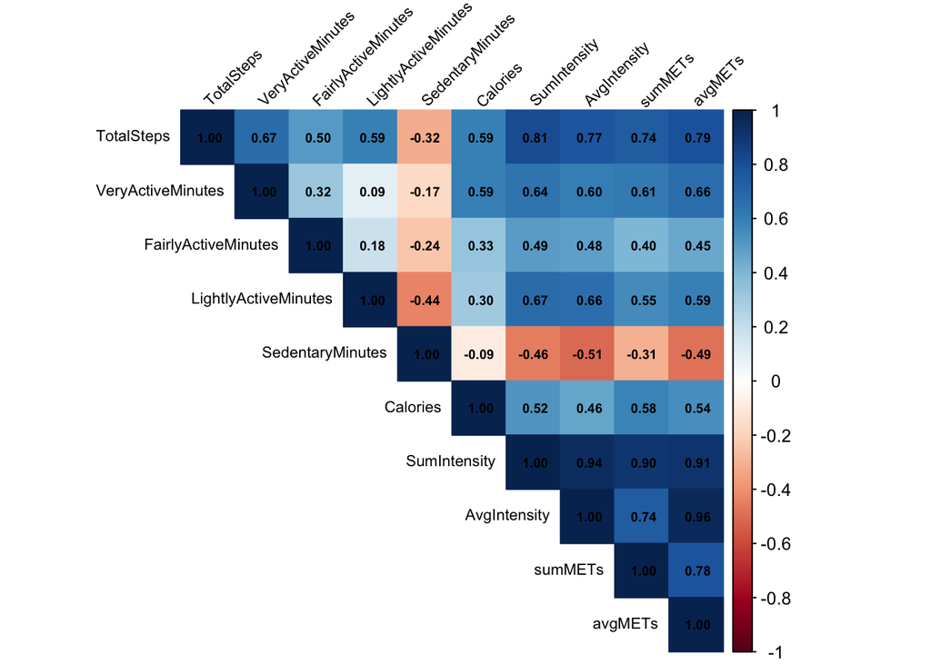

```r
library(corrplot)
corrplot(
    correlation_act,
    method = "color",
    type = "upper",
    addCoef.col = "black",
    number.cex = 0.6,
    tl.col = "black",
    tl.cex = 0.7,
    tl.srt = 45
)
```

Based on the correlation analysis, variables with very high correlations were considered redundant, and a representative metric was selected from each category.

- SumIntentisy was chosen as a major activity indicator because of very high correlations with AvgIntensity, sumMETs and avgMETs
- TotalSteps and SedentaryMinutes were kept as essential behavioral indicators
- VeryActiveMinutes and LightActiveMinutes were included because they show low correlations with eath other
- Calories was also chosen because it shows moderate correlations with most variables and provides an additional perspective on energy expenditure

### 8-3. User-Level Summary

These six features were primarily used to create user-level summary profiles. Two sleep-related measures were also included as supplementary indicators.

```r
user_summary <- master_table %>%
  group_by(Id) %>%
  summarise(

    DaysRecorded = n(),

    AvgSteps = mean(TotalSteps,na.rm = TRUE),
    SdSteps = sd(TotalSteps,na.rm = TRUE),

    AvgVeryActiveM = mean(VeryActiveMinutes,na.rm = TRUE),
    AvgLightActiveM = mean(LightlyActiveMinutes,na.rm = TRUE),

    AvgSedenM = mean(SedentaryMinutes,na.rm = TRUE),
    SdSedenM = sd(SedentaryMinutes,na.rm = TRUE),

    AvgCalories = mean(Calories,na.rm = TRUE),

    AvgSumIntensity = mean(SumIntensity,na.rm = TRUE),
    SdSumIntensity = sd(SumIntensity,na.rm = TRUE),

    AvgSleepM = mean(TotalMinutesAsleep,na.rm = TRUE),
    SdSleepM = sd(TotalMinutesAsleep,na.rm = TRUE),
    AvgBedM = mean(TotalTimeInBed,na.rm = TRUE),
    SdBedM = sd(TotalTimeInBed,na.rm = TRUE),

    .groups = "drop"
  )

head(user_summary)
```

```
## # A tibble: 6 × 15
##        Id DaysRecorded AvgSteps SdSteps AvgVeryActiveM AvgLightActiveM AvgSedenM
##     <dbl>        <int>    <dbl>   <dbl>          <dbl>           <dbl>     <dbl>
## 1  1.50e9           50   11936.   3136.         37.6             223.       834.
## 2  1.62e9           50    5167.   5574.          5.66            141.      1266.
## 3  1.64e9           40    7781.   4697.         10.9             191.      1130.
## 4  1.84e9           43    2876.   2765.          0.302           127.      1159.
## 5  1.93e9           43    1269.   1435.          0.953            59.0     1216.
## 6  2.02e9           43   11595.   3106.         37.3             256.      1098.
## # ℹ 8 more variables: SdSedenM <dbl>, AvgCalories <dbl>, AvgSumIntensity <dbl>,
## #   SdSumIntensity <dbl>, AvgSleepM <dbl>, SdSleepM <dbl>, AvgBedM <dbl>,
## #   SdBedM <dbl>
```

```r
write_csv(user_summary,
          "data/cleaned_data/user_summary.csv")
```

### 8-4. User Segmentation

Before classifying users into groups, distributions of each primary variables should be visualized

```r
summary(user_summary)
```

```
##        Id             DaysRecorded     AvgSteps          SdSteps
##  Min.   :1.504e+09   Min.   : 8.0   Min.   :  773.6   Min.   :1435
##  1st Qu.:2.610e+09   1st Qu.:38.5   1st Qu.: 4446.1   1st Qu.:2799
##  Median :4.445e+09   Median :43.0   Median : 7299.3   Median :3539
##  Mean   :4.845e+09   Mean   :40.0   Mean   : 6989.0   Mean   :3588
##  3rd Qu.:6.869e+09   3rd Qu.:43.0   3rd Qu.: 8631.8   3rd Qu.:4239
##  Max.   :8.878e+09   Max.   :63.0   Max.   :16424.3   Max.   :6389
##
##  AvgVeryActiveM   AvgLightActiveM    AvgSedenM         SdSedenM
##  Min.   : 0.000   Min.   : 34.33   Min.   : 644.9   Min.   : 86.78
##  1st Qu.: 4.235   1st Qu.:135.00   1st Qu.: 781.9   1st Qu.:131.87
##  Median :10.033   Median :182.72   Median :1091.3   Median :196.22
##  Mean   :18.871   Mean   :182.47   Mean   :1004.2   Mean   :219.82
##  3rd Qu.:25.088   3rd Qu.:240.59   3rd Qu.:1187.4   3rd Qu.:286.33
##  Max.   :85.854   Max.   :314.23   Max.   :1342.4   Max.   :510.85
##
##   AvgCalories   AvgSumIntensity  SdSumIntensity     AvgSleepM
##  Min.   :1434   Min.   : 57.38   Min.   : 61.87   Min.   : 61.0
##  1st Qu.:1855   1st Qu.:172.08   1st Qu.: 88.76   1st Qu.:336.5
##  Median :2161   Median :298.67   Median :115.05   Median :426.6
##  Mean   :2250   Mean   :270.60   Mean   :119.46   Mean   :380.5
##  3rd Qu.:2616   3rd Qu.:355.10   3rd Qu.:141.41   3rd Qu.:457.4
##  Max.   :3429   Max.   :469.88   Max.   :243.94   Max.   :652.0
##                                                   NA's   :11
##     SdSleepM         AvgBedM          SdBedM
##  Min.   : 14.85   Min.   : 69.0   Min.   :  0.00
##  1st Qu.: 63.33   1st Qu.:378.6   1st Qu.: 67.39
##  Median : 84.11   Median :458.4   Median : 93.00
##  Mean   :102.49   Mean   :423.1   Mean   :107.10
##  3rd Qu.:110.44   3rd Qu.:492.0   3rd Qu.:115.77
##  Max.   :334.75   Max.   :961.0   Max.   :410.15
##  NA's   :12       NA's   :11      NA's   :12
```

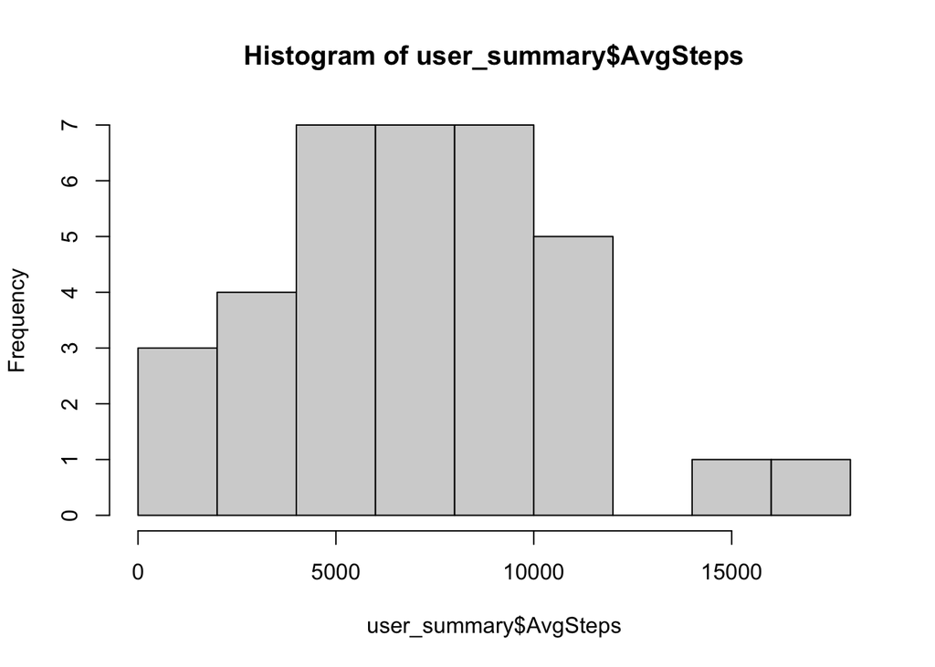

```r
hist(user_summary$AvgSteps)
```

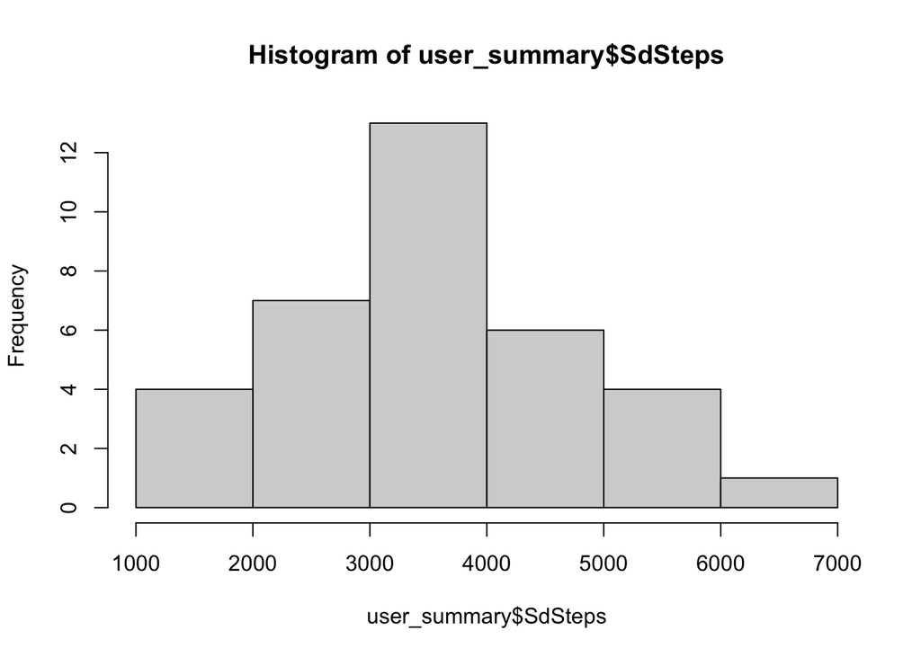

```r
hist(user_summary$SdSteps)
```

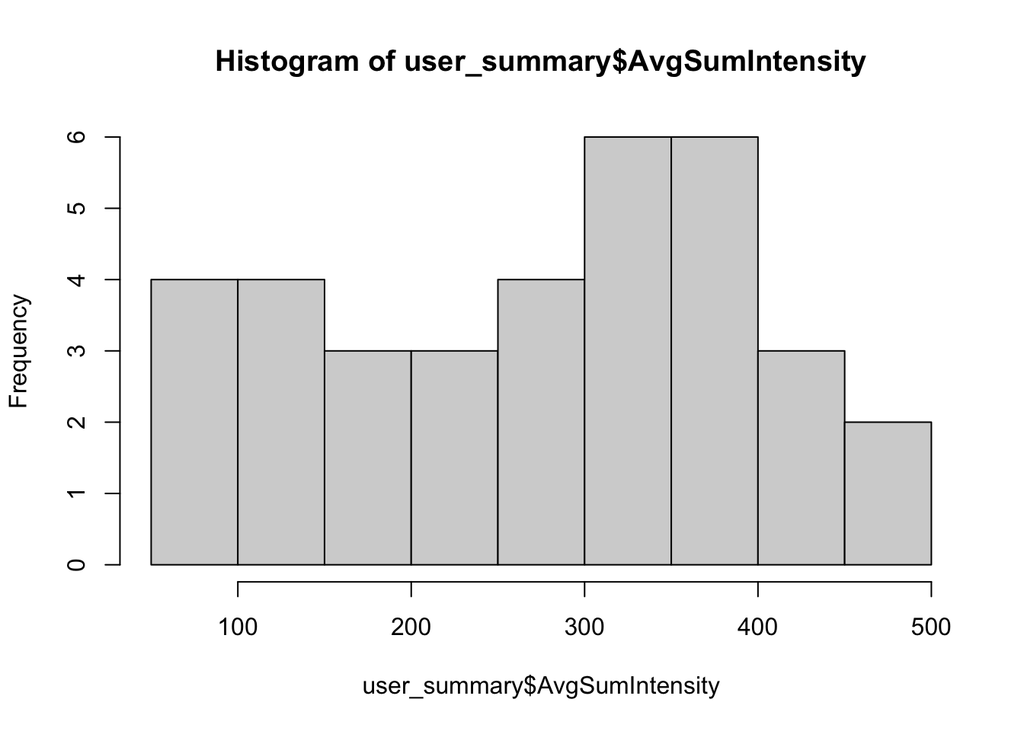

```r
hist(user_summary$AvgSumIntensity)
```

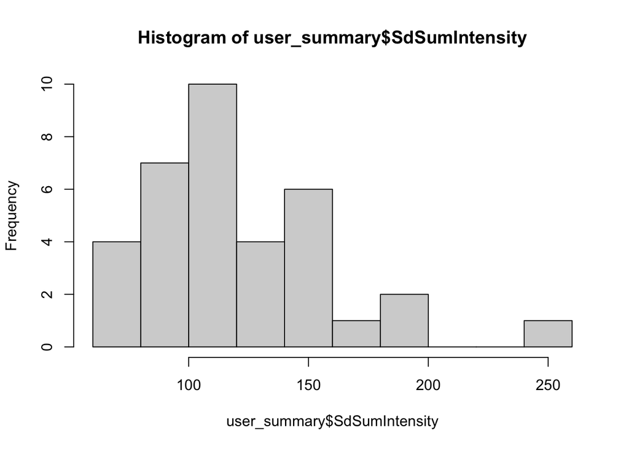

```r
hist(user_summary$SdSumIntensity)
```

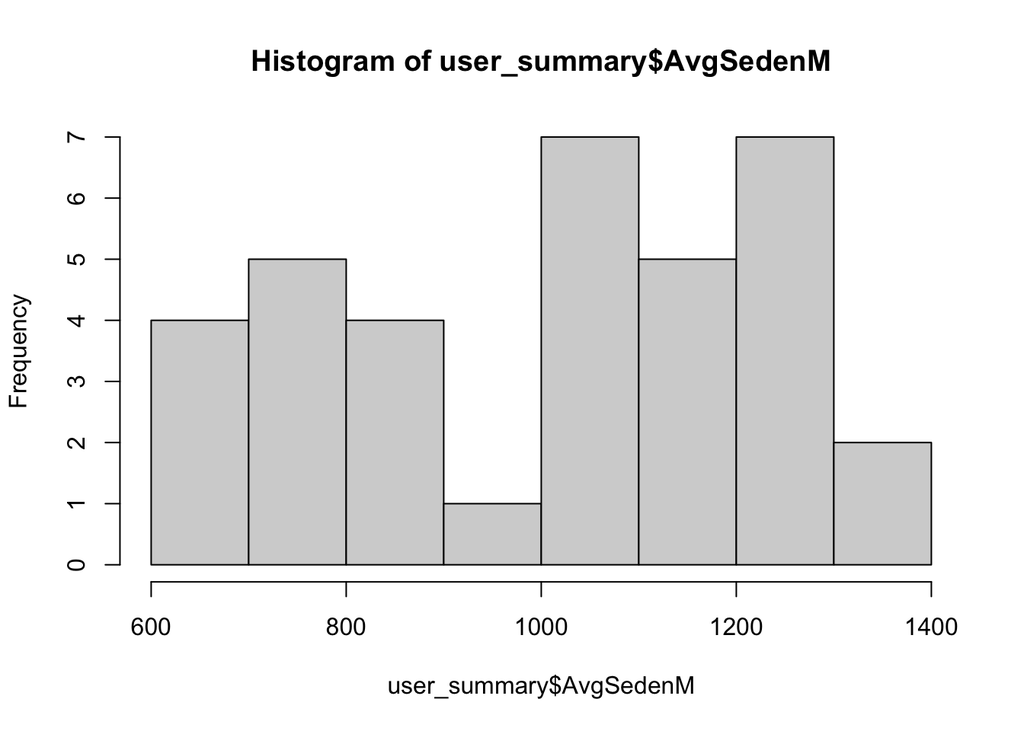

```r
hist(user_summary$AvgSedenM)
```

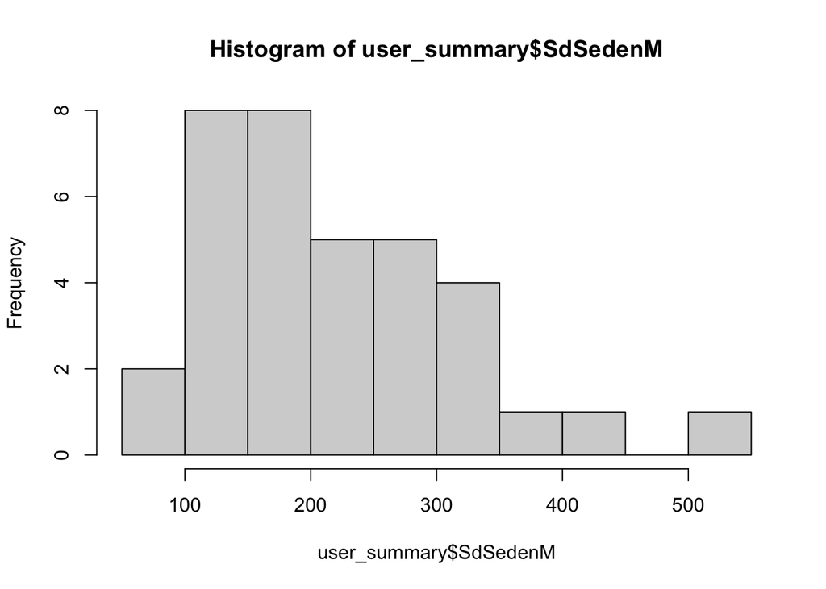

```r
hist(user_summary$SdSedenM)
```

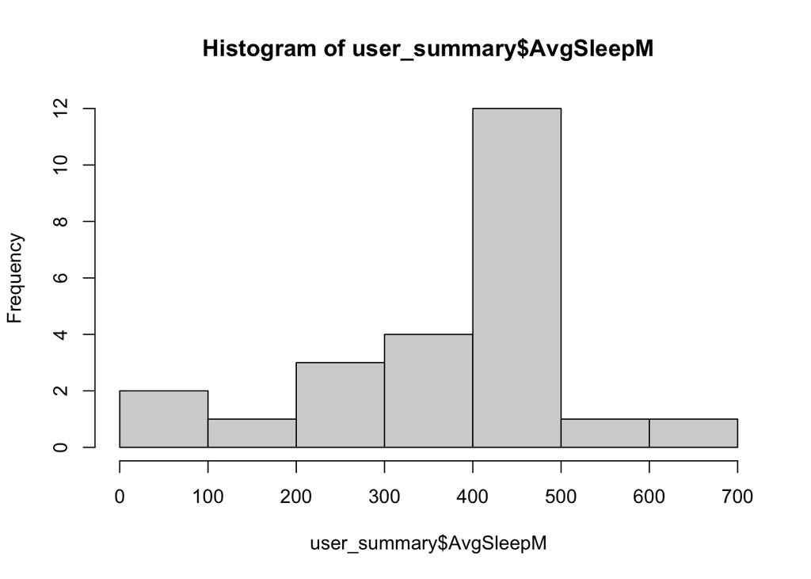

```r
hist(user_summary$AvgSleepM)
```

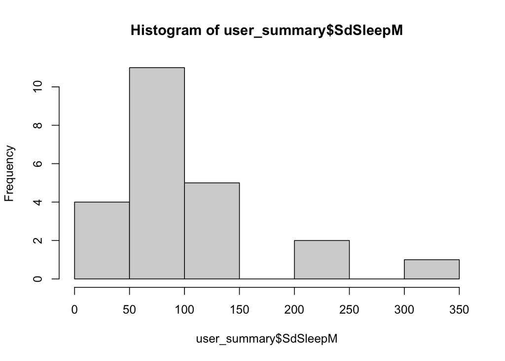

```r
hist(user_summary$SdSleepM)
```

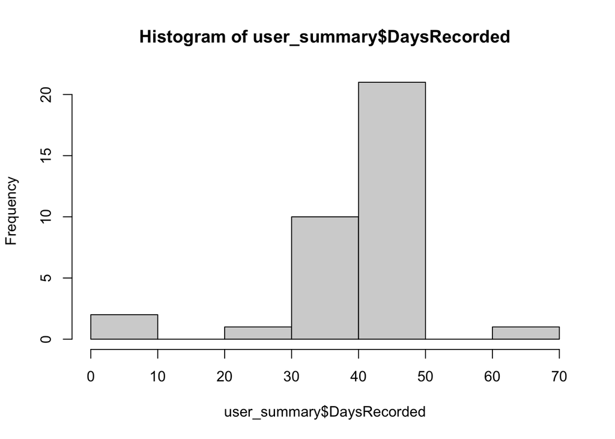

```r
hist(user_summary$DaysRecorded)
```

User groups were defined using rule-based thresholds derived from the data distribution.

- The third quartile (75th percentile) was used to identify Consistent Active Users, while the first quartile (25th percentile) and the number of days recorded were used for Low Engagement Users.
- Standard deviation measures were used to capture Irregular Users.
- Sleep length and variability were included as an optional indicator due to the limited data availability.

```r
user_summary<- user_summary %>%
  mutate(
    UserType = case_when(

      AvgSteps >= 8000 &
      AvgSumIntensity >= 350 &
      AvgSedenM <= 800
      ~ "Consistent Active Users",

      SdSteps >= 4000 |
      SdSumIntensity>=140 |
      SdSedenM >= 280 |
      SdSleepM >= 110
      ~ "Irregular Users",

      DaysRecorded <= 39 |
      AvgSteps <= 4500 |
      AvgSedenM >= 1100 |
      AvgSleepM <= 340
      ~ "Low Engagement Users",

      TRUE
      ~ "Moderate Users"
    )
  )

head(user_summary)
```

```
## # A tibble: 6 × 16
##        Id DaysRecorded AvgSteps SdSteps AvgVeryActiveM AvgLightActiveM AvgSedenM
##     <dbl>        <int>    <dbl>   <dbl>          <dbl>           <dbl>     <dbl>
## 1  1.50e9           50   11936.   3136.         37.6             223.       834.
## 2  1.62e9           50    5167.   5574.          5.66            141.      1266.
## 3  1.64e9           40    7781.   4697.         10.9             191.      1130.
## 4  1.84e9           43    2876.   2765.          0.302           127.      1159.
## 5  1.93e9           43    1269.   1435.          0.953            59.0     1216.
## 6  2.02e9           43   11595.   3106.         37.3             256.      1098.
## # ℹ 9 more variables: SdSedenM <dbl>, AvgCalories <dbl>, AvgSumIntensity <dbl>,
## #   SdSumIntensity <dbl>, AvgSleepM <dbl>, SdSleepM <dbl>, AvgBedM <dbl>,
## #   SdBedM <dbl>, UserType <chr>
```

```r
table(user_summary$UserType)
```

```
##
## Consistent Active Users         Irregular Users    Low Engagement Users
##                       5                      17                       8
##          Moderate Users
##                       5
```

```r
write_csv(user_summary,
          "data/cleaned_data/user_summary.csv")
```

```r
user_type_analysis <- user_summary %>%
  group_by(UserType) %>%
  summarise(
    Users = n(),

    AvgSteps = round(mean(AvgSteps),0),
    AvgSdSteps = round(mean(SdSteps),0),
    AvgIntensity = round(mean(AvgSumIntensity),0),
    AvgSdIntensity = round(mean(SdSumIntensity),0),
    AvgSedentary = round(mean(AvgSedenM),0),
    AvgSdSedentary = round(mean(SdSedenM),0),
    AvgSleep = round(mean(AvgSleepM,na.rm = TRUE),0),
    AvgDays = round(mean(DaysRecorded),1)
  )

user_type_analysis
```

```
## # A tibble: 4 × 10
##   UserType    Users AvgSteps AvgSdSteps AvgIntensity AvgSdIntensity AvgSedentary
##   <chr>       <int>    <dbl>      <dbl>        <dbl>          <dbl>        <dbl>
## 1 Consistent…     5     9535       3910          383            138          695
## 2 Irregular …    17     6589       4035          238            133         1048
## 3 Low Engage…     8     5414       2876          240             98         1206
## 4 Moderate U…     5     8324       2887          317             89          840
## # ℹ 3 more variables: AvgSdSedentary <dbl>, AvgSleep <dbl>, AvgDays <dbl>
```

```r
write_csv(user_type_analysis,
          "data/cleaned_data/user_type_analysis.csv")
```

### (8-5. Check the Sleep Data Reliability)

The average sleep minutes of Low Engagement Users seems unusual. The number should be investigated before going the next section (Business Insight).

```r
user_summary %>%
  filter(UserType =="Low Engagement Users") %>%
  select(Id,AvgSleepM)
```

```
## # A tibble: 8 × 2
##           Id AvgSleepM
##        <dbl>     <dbl>
## 1 2320127002       61
## 2 2873212765      NaN
## 3 3372868164      NaN
## 4 4057192912      NaN
## 5 4558609924      128.
## 6 6290855005      NaN
## 7 8253242879      NaN
## 8 8583815059      NaN
```

Most sleep records were missing for Low Engagement Users, and the available values were very low.

## 9. Business Insight

### 9-1. Visualise User Groups

The four user groups were visualized to differentiate their characteristics

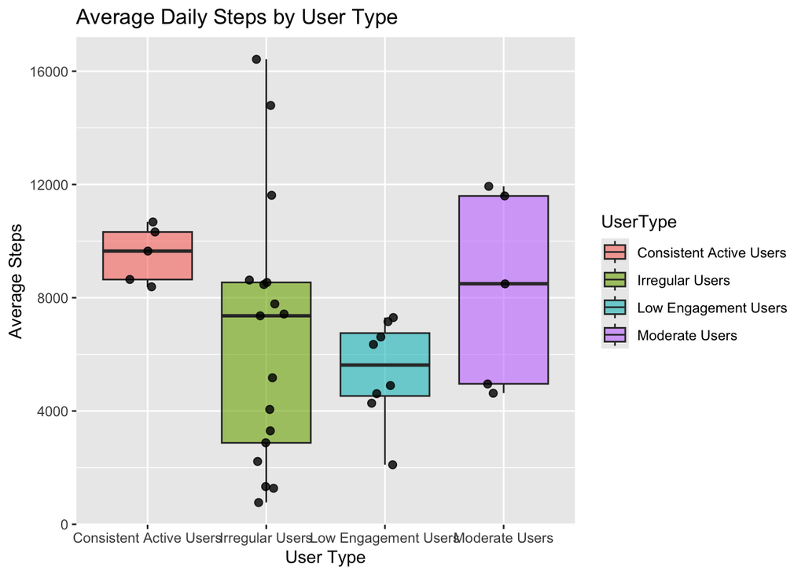

```r
ggplot(user_summary,
       aes(x = UserType,
           y = AvgSteps)) +
    geom_boxplot(
        aes(fill = UserType),
        alpha = 0.6
    ) +
    geom_jitter(
        width = 0.15,
        size = 2,
        alpha = 0.8,
        color = "black"
    ) +
    labs(title = "Average Daily Steps by User Type",
         x = "User Type",
         y = "Average Steps")
```

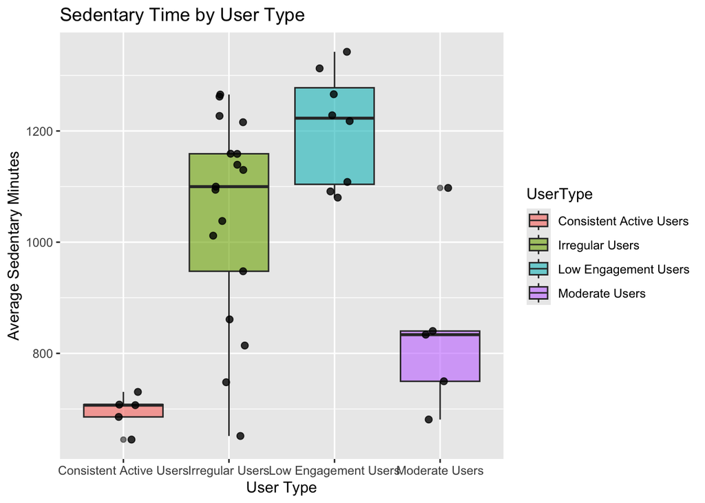

```r
ggplot(user_summary,
       aes(x = UserType,
           y = AvgSedenM)) +
    geom_boxplot(
        aes(fill = UserType),
        alpha = 0.6
    ) +
    geom_jitter(
        width = 0.15,
        size = 2,
        alpha = 0.8,
        color = "black"
    ) +
    labs(title = "Sedentary Time by User Type",
         x = "User Type",
         y = "Average Sedentary Minutes")
```

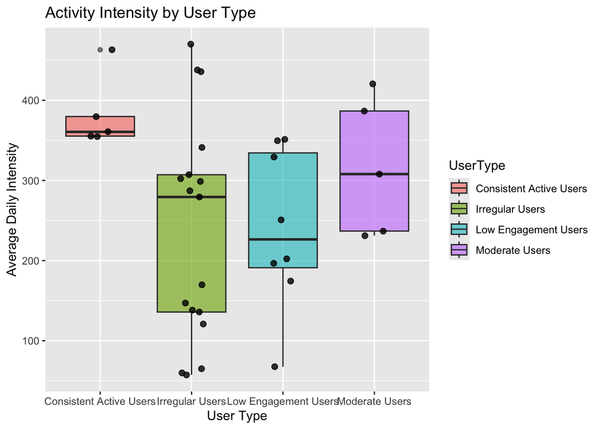

```r
ggplot(user_summary,
       aes(x = UserType,
           y = AvgSumIntensity)) +
    geom_boxplot(
        aes(fill = UserType),
        alpha = 0.6
    ) +
    geom_jitter(
        width = 0.15,
        size = 2,
        alpha = 0.8,
        color = "black"
    ) +
    labs(title = "Activity Intensity by User Type",
         x = "User Type",
         y = "Average Daily Intensity")
```

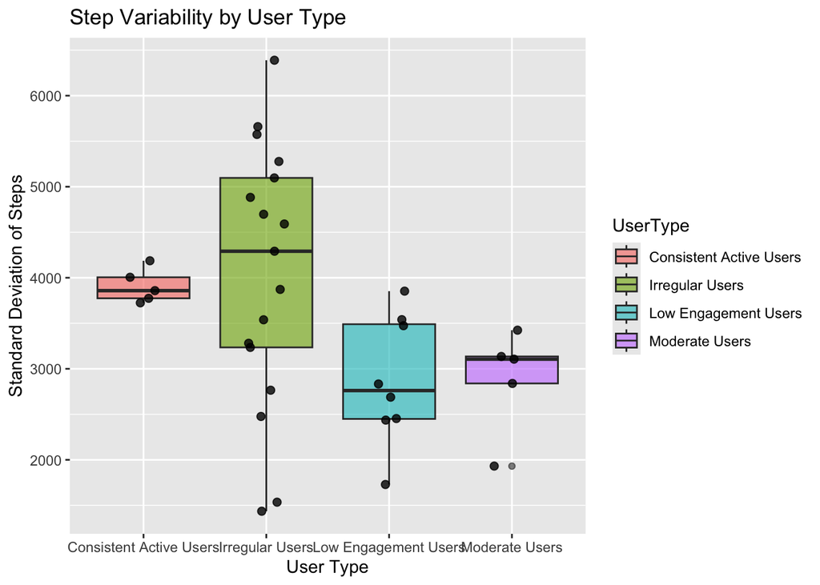

```r
ggplot(user_summary,
       aes(x = UserType,
           y = SdSteps)) +
    geom_boxplot(
        aes(fill = UserType),
        alpha = 0.6
    ) +
    geom_jitter(
        width = 0.15,
        size = 2,
        alpha = 0.8,
        color = "black"
    ) +
    labs(title = "Step Variability by User Type",
         x = "User Type",
         y = "Standard Deviation of Steps")
```

## 10. Actionable Recommendations

- Consistent Active Users: Introduce advanced performance tracking features, achievement badges and reward systems in subscription benefits to maintain their momentum among highly active users.
- Irregular Users: Send reminders through healthcare applications to encourage consistent daily activity, especially when users fall behind their recent average activity levels.
- Low Engagement Users: Strengthen gamification features in the applications that provide frequent and achievable rewards. For instance, users can earn points simply by standing up and moving regularly throughout the day in order to reduce sedentary time. This makes them feel a sense of small but healthy accomplishment.
- Moderate Users: Focus on long-term education and strategies rather than short-term promotional campaigns. Notify gradual progress over time, such as stamina, sleep quality, calculated body age.